# Logistic Regression for Loansharks (2014 Pennsylvania)

4/5/2020

## We tried the following glm models. The predictors chosen were picked

## from our EDA analysis and feature engineering work and some background

## knowledge.

# Model 1. Raw loan and applicant income.

# Model 2. Log of loan and applicant income.

# Model 3. Log of loan amount and loan to income ratio.

# Model 4. Cross validation model with same predictors as Model 3.

# Model 5. Merged model with hmda data and census demographic and ethnicity

# data. We removed the minority_population column from the HMDA data

# and replaced it with predictors like BLACK_PERCENT, ASIAN_PERCENT, # etc. We were trying to see if African Americans were negatively

# impacted if they applied for loans in areas where the BLACK_PERCENT

# was high, etc.

# Model 6. Merged model with median loan to value ratio coming from Zillow.

# Banks use the loan to value ratio as one of the criterion in loan

# decisions. As HMDA data does not have this information, we thought

# we could approximate this by using the median home values in the

# county.

## Results.

# Model 2, Model 3 and Model 4 performed similarly. The criterion was AUC

# curve, Mcfadden R square value and confusion matrix results on test data.

# Model 5 and Model 6 also performed well. However the results weren’t that

# different from the simpler models. Hence we opted for the simpler models.

# Model 3 was chosen as banks do use the loan to income ratio as one of their

# criterion.

## Key observation

# The AUC curve for our models ranges between 75 to 77%. The AUC curve can

# be thought of as a classification-threshold-invariant. It measures the

# quality of the model’s predictions irrespective of the threshold value

# https://developers.google.com/machine-learning/crash-course/classification/roc-and-auc.

# We feel that this is because our models miss crucial data like debt to income

# ratio, credit scores, etc which banks use as additional predictors.

## Global setup like working directory, data directory etc should happen here.

```r
library(sys)

working_directory <- getwd()

setwd(dirname(dirname(working_directory)))
```

```
The working directory was changed to D:/illinois/csp571/csp-571-02-final-project/src inside a notebook chunk. The working directory will be reset when the chunk is finished running. Use the knitr root.dir option in the setup chunk to change the working directory for notebook chunks.
```

```r
writeLines("")
```

```r
getwd()
```

```
[1] "D:/illinois/csp571/csp-571-02-final-project/src"
```

```r
# The HMDA dataset is loaded from here.
data_dir <- "D:/data"
census_data_dir = "d:/data/census"

# The models are saved in this directory.
model_path <- paste(dirname(rstudioapi::getActiveDocumentContext()$path), "models", sep = "/")
print(model_path)
```

```
[1] "D:/illinois/csp571/csp-571-02-final-project/src/train/2014/models"
```

```r
# The train and test data are saved in this directory
model_data_path <- paste(dirname(rstudioapi::getActiveDocumentContext()$path), "data", sep = "/")
print(model_data_path)
```

```
[1] "D:/illinois/csp571/csp-571-02-final-project/src/train/2014/data"
```

```r
options(scipen = 999)
```

## Install required packages.

```r
# https://stackoverflow.com/questions/4090169/elegant-way-to-check-for-missing-packages-and-install-them
list_of_packages <- c("mlbench", "corrplot", "rvest", "tidyr", "stringr", "dplyr", "lubridate", "data.table", "mice", "scales", "naniar", "rpart", "rpart.plot", "caret", "pROC", "ROCR")
new.packages <- list_of_packages[!(list_of_packages %in% installed.packages()[,"Package"])]

if (length(new.packages)) {
  print("Installing packages\n")
  install.packages(new.packages())
}

library(corrplot)
library(ggplot2)
library(tidyr)
library(stringr)
library(dplyr)
library(data.table)
library(mice)
library(rstudioapi)
library(naniar)
library(caret)
library(pROC)
library(ROCR)

source(paste(dirname(dirname(dirname(rstudioapi::getActiveDocumentContext()$path))), "utils/utils.r", sep="/"))

source(paste(dirname(dirname(dirname(rstudioapi::getActiveDocumentContext()$path))), "utils/model_utils.r", sep="/"))
```

# Load the imputed hmda csv file.

```r
hmda_data_df_ <- fread(paste(data_dir, "/HMDA/2014/hmda_2014_pa_imputed.csv", sep=""))
```

```
|--------------------------------------------------|
|==================================================|
```

```r
hmda_data_df <- as.data.frame(hmda_data_df_)
```

# Explore the dataframe obtained above.

```r
head(hmda_data_df, 20)
```

|  | as_of_year | respondent_id | agency_name | agency_abbr | agency_code | loan_type_name | loan_type | property_type_name | property_type | loan_purpose_name | loan_purpose | owner_occupancy_name | owner_occupancy | loan_amount_000s | preapproval_name | preapproval | action_taken_name | action_taken | msamd_name | msamd | state_name | state_abbr | state_code | county_name | county_code | census_tract_number | applicant_ethnicity_name | applicant_ethnicity | co_applicant_ethnicity_name | … |
| --- | --- | --- | --- | --- | --- | --- | --- | --- | --- | --- | --- | --- | --- | --- | --- | --- | --- | --- | --- | --- | --- | --- | --- | --- | --- | --- | --- | --- | --- | --- |
| 1 | 2014 | 41-1795868 | Department of Housing and Urban Development | HUD | 7 | Conventional | 1 | One-to-four family dwelling (other than manufactured housing) | 1 | Refinancing | 3 | Owner-occupied as a principal dwelling | 1 | 81 | Not applicable | 3 | Application denied by financial institution | 3 |  | 27780 | Pennsylvania | PA | 42 | Lawrence County | 73 | 111.00 | Not Hispanic or Latino | 2 | No co-applicant | … |
| 2 | 2014 | 0000024891 | Office of the Comptroller of the Currency | OCC | 1 | Conventional | 1 | One-to-four family dwelling (other than manufactured housing) | 1 | Home purchase | 1 | Owner-occupied as a principal dwelling | 1 | 132 | Not applicable | 3 | Loan originated | 1 | York, Hanover - PA | 49620 | Pennsylvania | PA | 42 | York County | 133 | 207.10 | Not Hispanic or Latino | 2 | No co-applicant | … |
| 3 | 2014 | 62-1532940 | Department of Housing and Urban Development | HUD | 7 | Conventional | 1 | One-to-four family dwelling (other than manufactured housing) | 1 | Home purchase | 1 | Owner-occupied as a principal dwelling | 1 | 158 | Preapproval was not requested | 2 | Application denied by financial institution | 3 | Lancaster - PA | 29540 | Pennsylvania | PA | 42 | Lancaster County | 71 | 117.04 | Not Hispanic or Latino | 2 | No co-applicant | … |
| 4 | 2014 | 41-1795868 | Department of Housing and Urban Development | HUD | 7 | Conventional | 1 | One-to-four family dwelling (other than manufactured housing) | 1 | Refinancing | 3 | Owner-occupied as a principal dwelling | 1 | 236 | Not applicable | 3 | Application withdrawn by applicant | 4 | Montgomery County, Bucks County, Chester County - PA | 33874 | Pennsylvania | PA | 42 | Bucks County | 17 | 1016.03 | Not Hispanic or Latino | 2 | No co-applicant | … |
| 5 | 2014 | 0000057228 | Federal Deposit Insurance Corporation | FDIC | 3 | Conventional | 1 | One-to-four family dwelling (other than manufactured housing) | 1 | Refinancing | 3 | Owner-occupied as a principal dwelling | 1 | 53 | Not applicable | 3 | Loan originated | 1 | Allentown, Bethlehem, Easton - PA, NJ | 10900 | Pennsylvania | PA | 42 | Northampton County | 95 | 162.02 | Not Hispanic or Latino | 2 | No co-applicant | … |
| 6 | 2014 | 41-1795868 | Department of Housing and Urban Development | HUD | 7 | Conventional | 1 | One-to-four family dwelling (other than manufactured housing) | 1 | Home purchase | 1 | Not owner-occupied as a principal dwelling | 2 | 150 | Not applicable | 3 | Loan purchased by the institution | 6 | Montgomery County, Bucks County, Chester County - PA | 33874 | Pennsylvania | PA | 42 | Bucks County | 17 | 1055.10 | Not applicable | 4 | Not applicable | … |
| 7 | 2014 | 0000028178 | Federal Deposit Insurance Corporation | FDIC | 3 | Conventional | 1 | One-to-four family dwelling (other than manufactured housing) | 1 | Home purchase | 1 | Owner-occupied as a principal dwelling | 1 | 108 | Not applicable | 3 | Loan originated | 1 |  | 38300 | Pennsylvania | PA | 42 | Elk County | 47 | 9511.00 | Not Hispanic or Latino | 2 | No co-applicant | … |
| 8 | 2014 | 0000002099 | National Credit Union Administration | NCUA | 5 | Conventional | 1 | One-to-four family dwelling (other than manufactured housing) | 1 | Refinancing | 3 | Owner-occupied as a principal dwelling | 1 | 265 | Not applicable | 3 | Loan originated | 1 | Montgomery County, Bucks County, Chester County - PA | 33874 | Pennsylvania | PA | 42 | Chester County | 29 | 3044.05 | Not Hispanic or Latino | 2 | Not Hispanic or Latino | … |
| 9 | 2014 | 75-2921540 | Department of Housing and Urban Development | HUD | 7 | Conventional | 1 | One-to-four family dwelling (other than manufactured housing) | 1 | Refinancing | 3 | Owner-occupied as a principal dwelling | 1 | 196 | Not applicable | 3 | Application denied by financial institution | 3 |  | 37964 | Pennsylvania | PA | 42 | Schuylkill County | 107 | 38.00 | Information not provided by applicant in mail, Internet, or telephone application | 3 | Information not provided by applicant in mail, Internet, or telephone application | … |
| 10 | 2014 | 41-1795868 | Department of Housing and Urban Development | HUD | 7 | Conventional | 1 | One-to-four family dwelling (other than manufactured housing) | 1 | Refinancing | 3 | Owner-occupied as a principal dwelling | 1 | 67 | Not applicable | 3 | Loan originated | 1 | Harrisburg, Carlisle - PA | 25420 | Pennsylvania | PA | 42 | Dauphin County | 43 | 230.00 | Not Hispanic or Latino | 2 | No co-applicant | … |

[output cut: 10 more lines]

```r
# Ignore action values of 4 : Application withdrawn by applicant
# 6: Loan purchased by the institution and 2: Application approved but
# not accepted.
# The remaining action types are 1: Loan originated, 3. Application denied
# by financial institution, 5. File closed for incompleteness and 7. Preapproval
# request denied by financial institution.
hmda_data_df <- hmda_data_df[hmda_data_df$action_taken != 2 & hmda_data_df$action_taken != 4 & hmda_data_df$action_taken != 6, ]
```

# Create dataframe based on selected column list from the source dataframe.

```r
hmda_data_df_for_model <- hmda_data_frame_for_model(hmda_data_df)
hmda_data_df_for_model <- process_model_df_columns(hmda_data_df_for_model)
```

# Explore the dataframe with selected columns obtained above.

```r
head(hmda_data_df_for_model, 20)
```

|  | applicant_race_and_ethnicity | applicant_income_000s | co_applicant_race_and_ethnicity | co_applicant_sex | county_name | hoepa_status | lien_status | msamd | owner_occupancy | preapproval | purchaser_type | property_type | loan_amount_000s | applicant_sex | hud_median_family_income | tract_to_msamd_income | loan_to_income_ratio | agency_code | minority_population | loan_purpose | rate_spread | population | number_of_owner_occupied_units | loan_granted | log_loan_amount_000s | log_applicant_income_000s | credit_score | co_applicant_present | respondent_id | … |
| --- | --- | --- | --- | --- | --- | --- | --- | --- | --- | --- | --- | --- | --- | --- | --- | --- | --- | --- | --- | --- | --- | --- | --- | --- | --- | --- | --- | --- | --- | --- |
| 1 | White | 30 | No co-applicant | 5 | Lawrence County | 2 | 1 | 27780 | 1 | 3 | 0 | 1 | 81 | 1 | 54100 | 96.77 | 2.700000 | 7 | 2.53 | 3 | 2.06 | 4182 | 1261 | no | 4.394449 | 3.401197 | 734 | 0 | 41-1795868 | … |
| 2 | White | 49 | No co-applicant | 5 | York County | 2 | 1 | 49620 | 1 | 3 | 3 | 1 | 132 | 1 | 68700 | 93.10 | 2.693878 | 1 | 10.74 | 1 | 1.50 | 6517 | 2130 | yes | 4.882802 | 3.891820 | 734 | 0 | 0000024891 | … |
| 3 | White | 76 | No co-applicant | 5 | Lancaster County | 2 | 1 | 29540 | 1 | 2 | 0 | 1 | 158 | 2 | 67200 | 161.91 | 2.078947 | 7 | 14.19 | 1 | 1.54 | 4340 | 1362 | no | 5.062595 | 4.330733 | 734 | 0 | 62-1532940 | … |
| 5 | White | 53 | No co-applicant | 5 | Northampton County | 2 | 1 | 10900 | 1 | 3 | 0 | 1 | 53 | 2 | 68800 | 102.17 | 1.000000 | 3 | 6.07 | 3 | 2.40 | 4351 | 1329 | yes | 3.970292 | 3.970292 | 734 | 0 | other | … |
| 7 | White | 36 | No co-applicant | 5 | Elk County | 2 | 1 | 38300 | 1 | 3 | 0 | 1 | 108 | 1 | 54100 | 106.73 | 3.000000 | 3 | 1.94 | 1 | 1.74 | 5669 | 1822 | yes | 4.682131 | 3.583519 | 734 | 0 | 0000028178 | … |
| 8 | White | 145 | White | 2 | Chester County | 2 | 1 | 33874 | 1 | 3 | 0 | 1 | 265 | 1 | 95400 | 135.67 | 1.827586 | 5 | 11.00 | 3 | 1.61 | 6319 | 1964 | yes | 5.579730 | 4.976734 | 734 | 1 | 0000002099 | … |
| 9 | No Information Provided | 110 | Information not provided by applicant in mail, Internet, or telephone application | 3 | Schuylkill County | 2 | 1 | 37964 | 1 | 3 | 0 | 1 | 196 | 3 | 54100 | 120.48 | 1.781818 | 7 | 4.39 | 3 | 1.68 | 2186 | 552 | no | 5.278115 | 4.700480 | 732 | 0 | 75-2921540 | … |
| 10 | White | 19 | No co-applicant | 5 | Dauphin County | 2 | 1 | 25420 | 1 | 3 | 1 | 1 | 67 | 2 | 71500 | 105.73 | 3.526316 | 7 | 21.44 | 3 | 1.96 | 1824 | 590 | yes | 4.204693 | 2.944439 | 734 | 0 | 41-1795868 | … |
| 11 | White | 48 | No co-applicant | 5 | Franklin County | 2 | 1 | 16540 | 1 | 3 | 1 | 1 | 185 | 1 | 60800 | 121.21 | 3.854167 | 7 | 6.12 | 3 | 1.76 | 6259 | 2155 | yes | 5.220356 | 3.871201 | 734 | 0 | 26-4599244 | … |
| 14 | No Information Provided | 146 | Information not provided by applicant in mail, Internet, or telephone application | 3 | Bucks County | 2 | 1 | 33874 | 1 | 3 | 0 | 1 | 200 | 3 | 95400 | 106.69 | 1.369863 | 7 | 6.40 | 1 | 3.55 | 6574 | 1930 | yes | 5.298317 | 4.983607 | 732 | 0 | other | … |

[output cut: 10 more lines]

```r
nrow(hmda_data_df_for_model)
```

```
[1] 256227
```

```r
length(levels(hmda_data_df_for_model$respondent_id))
```

```
[1] 51
```

```r
length(levels(hmda_data_df_for_model$county_code))
```

```
[1] 26
```

# Train/test split.

```r
set.seed(400)

split_dfs <- train_test_split(hmda_data_df_for_model$loan_granted, hmda_data_df_for_model)

train <- split_dfs[[1]]
test <- split_dfs[[2]]
```

# Null model

```
Call:
glm(formula = as.formula(model_formula), family = binomial(link = "logit"),
    data = train_df, control = glm.control(maxit = iter))

Deviance Residuals:
    Min       1Q   Median       3Q      Max
-1.5509  -1.5509   0.8453   0.8453   0.8453

Coefficients:
            Estimate Std. Error z value            Pr(>|z|)
(Intercept) 0.845345   0.004818   175.5 <0.0000000000000002 ***
---
Signif. codes:  0 ‘***’ 0.001 ‘**’ 0.01 ‘*’ 0.05 ‘.’ 0.1 ‘ ’ 1

(Dispersion parameter for binomial family taken to be 1)

    Null deviance: 250576  on 204982  degrees of freedom
Residual deviance: 250576  on 204982  degrees of freedom
AIC: 250578

Number of Fisher Scoring iterations: 4


Running predictions on null model
[1] "Accuracy 0.699594098821325"
[1] "Precision found"
```

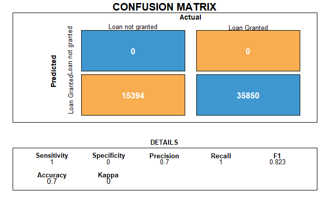

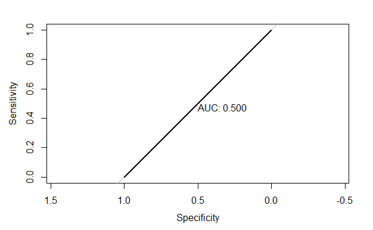

```r
null_model <- build_and_evaluate_hmda_null_model("loan_granted~1", train, test)
```

# Model with applicant income and loan amount.

```
Model summary


Call:
glm(formula = as.formula(model_formula), family = binomial(link = "logit"),
    data = train_df, control = glm.control(maxit = iter))

Deviance Residuals:
    Min       1Q   Median       3Q      Max
-3.9456  -0.8814   0.5225   0.8023   2.4092

Coefficients:
                                                                         Estimate
(Intercept)                                                            0.08033674
applicant_race_and_ethnicityAsian                                      0.46145927
applicant_race_and_ethnicityBlack or African American                  0.18401395
applicant_race_and_ethnicityHispanic or Latino                         0.18861190
applicant_race_and_ethnicityNative Hawaiian or Other Pacific Islander  0.28692134
applicant_race_and_ethnicityNo Information Provided                    0.38197854
applicant_race_and_ethnicityNot applicable                            -0.51102760
applicant_race_and_ethnicityWhite                                      0.73979518
applicant_income_000s                                                  0.00058022
loan_amount_000s                                                      -0.00002567
preapproval2                                                          -0.26349458
preapproval3                                                          -0.25871406
co_applicant_present1                                                  0.30945498
county_code11                                                         -0.01294018
county_code125                                                         0.16013555
county_code129                                                         0.17440550
county_code133                                                         0.05558845
county_code17                                                          0.14851181
county_code19                                                          0.32125490
county_code27                                                          0.29451048
county_code29                                                          0.18033049
county_code3                                                           0.16498738
county_code41                                                          0.19567461
county_code43                                                          0.12111785
county_code45                                                         -0.19979121
county_code49                                                          0.02430733
county_code51                                                         -0.01395552
```

[output cut: 499 more lines]

```
respondent_id7734800004                                               ***
respondent_id7774500004                                               ***
respondent_idother                                                    ***
---
Signif. codes:  0 ‘***’ 0.001 ‘**’ 0.01 ‘*’ 0.05 ‘.’ 0.1 ‘ ’ 1

(Dispersion parameter for binomial family taken to be 1)

    Null deviance: 250576  on 204982  degrees of freedom
Residual deviance: 211774  on 204878  degrees of freedom
AIC: 211984

Number of Fisher Scoring iterations: 6

Anova for model
```

[output not shown]

```
Analysis of Deviance Table

Model: binomial, link: logit

Response: loan_granted

Terms added sequentially (first to last)

                             Df Deviance Resid. Df Resid. Dev
NULL                                        204982     250576
applicant_race_and_ethnicity  7   7939.9    204975     242636
applicant_income_000s         1   1461.7    204974     241174
loan_amount_000s              1    735.8    204973     240439
preapproval                   2   3476.8    204971     236962
co_applicant_present          1   1276.2    204970     235686
county_code                  25    976.9    204945     234709
minority_population           1    716.2    204944     233992
loan_purpose                  2   8457.9    204942     225535
tract_to_msamd_income         1    352.7    204941     225182
applicant_sex                 3     26.8    204938     225155
property_type                 2   1406.0    204936     223749
owner_occupancy               2     35.5    204934     223714
agency_code                   5   2836.7    204929     220877
rate_spread                   1    410.5    204928     220466
respondent_id                50   8692.1    204878     211774
                                          Pr(>Chi)
NULL
applicant_race_and_ethnicity < 0.00000000000000022 ***
applicant_income_000s        < 0.00000000000000022 ***
loan_amount_000s             < 0.00000000000000022 ***
preapproval                  < 0.00000000000000022 ***
co_applicant_present         < 0.00000000000000022 ***
county_code                  < 0.00000000000000022 ***
minority_population          < 0.00000000000000022 ***
loan_purpose                 < 0.00000000000000022 ***
tract_to_msamd_income        < 0.00000000000000022 ***
applicant_sex                        0.00000638145 ***
property_type                < 0.00000000000000022 ***
owner_occupancy                      0.00000001911 ***
agency_code                  < 0.00000000000000022 ***
rate_spread                  < 0.00000000000000022 ***
respondent_id                < 0.00000000000000022 ***
---
Signif. codes:  0 ‘***’ 0.001 ‘**’ 0.01 ‘*’ 0.05 ‘.’ 0.1 ‘ ’ 1
```

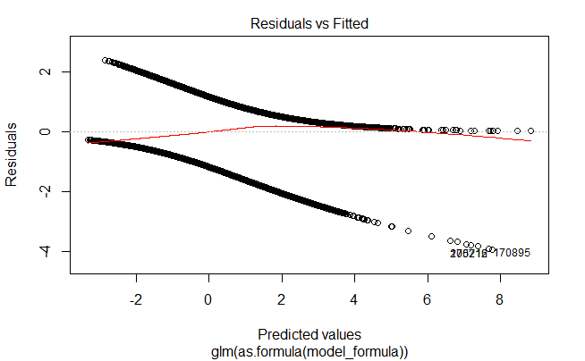

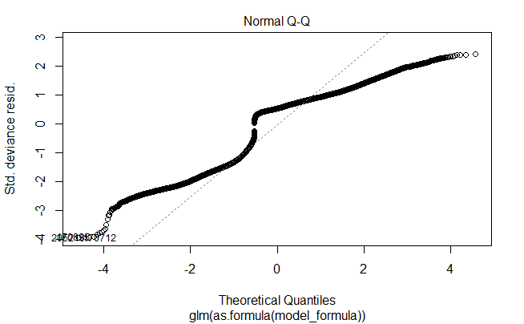

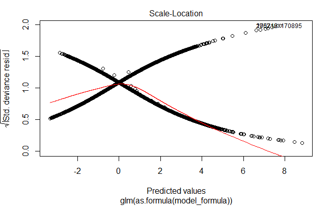

```
optimal cut threshold is
                 [,1]
sensitivity 0.6877075
specificity 0.6942789
cutoff      0.7021060
```

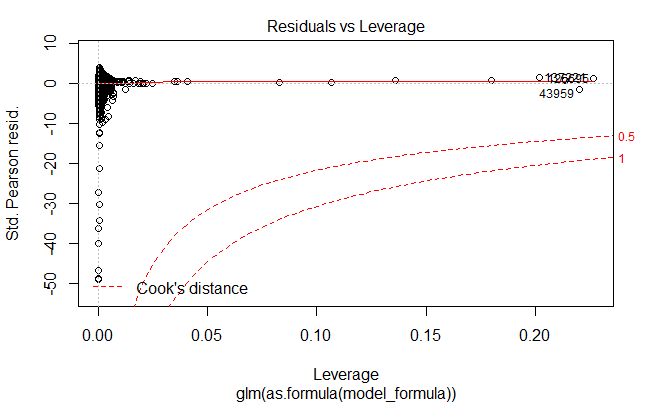

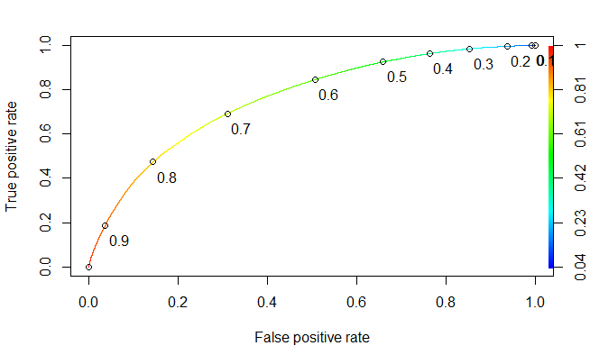

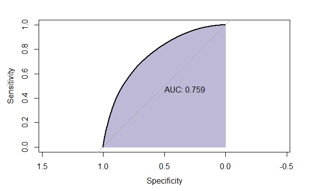

```r
model_2014_income_loan_amount <-
build_glm_model("loan_granted~applicant_race_and_ethnicity+applicant_income_000s+loan_amount_000s+preapproval+co_applicant_present+county_code+minority_population+loan_purpose+tract_to_msamd_income+applicant_sex+property_type+owner_occupancy+agency_code+rate_spread+respondent_id", train)

model_summary_and_plot(model_2014_income_loan_amount, train)
```

```r
mcfadden_r_square(model_2014_income_loan_amount, null_model)
```

```
Mcfadden Rsquare value
'log Lik.' 0.1548499 (df=105)
```

# Model with logs of applicant income and loan amount.

```
Model summary


Call:
glm(formula = as.formula(model_formula), family = binomial(link = "logit"),
    data = train_df, control = glm.control(maxit = iter))

Deviance Residuals:
    Min       1Q   Median       3Q      Max
-3.0711  -0.8669   0.5176   0.7942   2.4983

Coefficients:
                                                                        Estimate
(Intercept)                                                           -0.9939703
applicant_race_and_ethnicityAsian                                      0.4553455
applicant_race_and_ethnicityBlack or African American                  0.1591514
applicant_race_and_ethnicityHispanic or Latino                         0.2014833
applicant_race_and_ethnicityNative Hawaiian or Other Pacific Islander  0.2803005
applicant_race_and_ethnicityNo Information Provided                    0.2862880
applicant_race_and_ethnicityNot applicable                            -0.7243509
applicant_race_and_ethnicityWhite                                      0.7181866
log_applicant_income_000s                                              0.3964933
log_loan_amount_000s                                                  -0.0575778
preapproval2                                                          -0.2673315
preapproval3                                                          -0.2694334
co_applicant_present1                                                  0.1764983
county_code11                                                         -0.0247533
county_code125                                                         0.1261259
county_code129                                                         0.1613226
county_code133                                                         0.0445155
county_code17                                                          0.0519812
county_code19                                                          0.2962985
county_code27                                                          0.2629697
county_code29                                                          0.0742053
county_code3                                                           0.1337172
county_code41                                                          0.1726399
county_code43                                                          0.0964077
county_code45                                                         -0.1916889
county_code49                                                          0.0321717
county_code51                                                         -0.0422507
```

[output cut: 543 more lines]

```
log_loan_amount_000s         < 0.00000000000000022 ***
preapproval                  < 0.00000000000000022 ***
co_applicant_present         < 0.00000000000000022 ***
county_code                  < 0.00000000000000022 ***
tract_to_msamd_income        < 0.00000000000000022 ***
loan_purpose                 < 0.00000000000000022 ***
owner_occupancy              < 0.00000000000000022 ***
respondent_id                < 0.00000000000000022 ***
minority_population          < 0.00000000000000022 ***
rate_spread                  < 0.00000000000000022 ***
agency_code                  < 0.00000000000000022 ***
applicant_sex                            0.0002927 ***
property_type                < 0.00000000000000022 ***
---
Signif. codes:  0 ‘***’ 0.001 ‘**’ 0.01 ‘*’ 0.05 ‘.’ 0.1 ‘ ’ 1
```

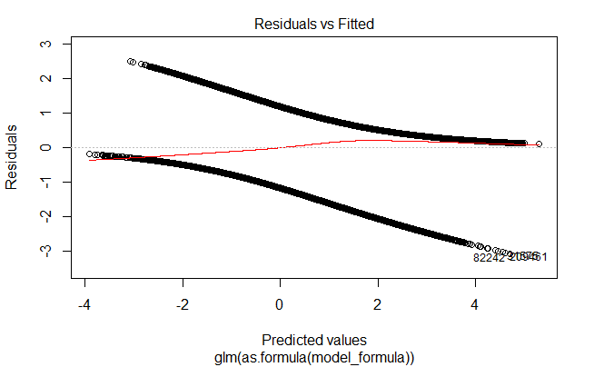

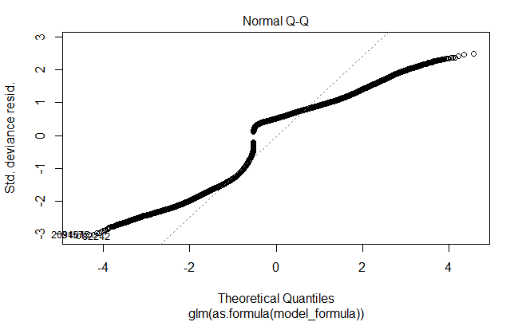

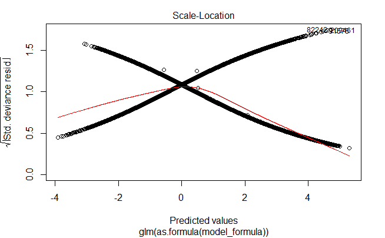

```
optimal cut threshold is
                 [,1]
sensitivity 0.7007685
specificity 0.6903652
cutoff      0.7002764
```

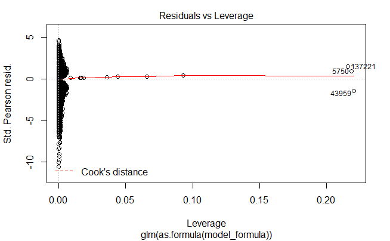

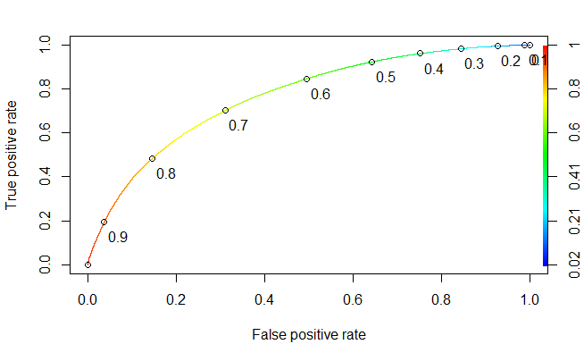

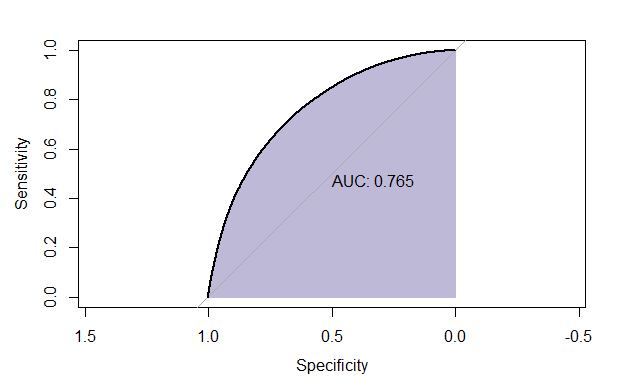

```r
model_2014_log_income_loan_amount <- build_glm_model("loan_granted~applicant_race_and_ethnicity+log_applicant_income_000s+log_loan_amount_000s+preapproval+co_applicant_present+county_code+tract_to_msamd_income+loan_purpose+owner_occupancy+respondent_id+minority_population+rate_spread+agency_code+applicant_sex+property_type", train)

model_summary_and_plot(model_2014_log_income_loan_amount, train)
```

```r
mcfadden_r_square(model_2014_log_income_loan_amount, null_model)
```

```
Mcfadden Rsquare value
'log Lik.' 0.161848 (df=105)
```